# News Article Analysis 3.0

## Sentiment Analysis

Use Sentiment Analysis technique, to check **Sentiment Score** of each article.

Then sort all articles by date and present it in table using **Pandas**.

We can also visualize results in plot chart using **MatPlotLib**.

### Sentiment dictionary

First process the **OpinionFinder_Lexicon.tff**, calculate the sentiment strength and polarity. Sentiment score of single word can be:

Neural = ignore ; Weak Positive = 1 ; Weak Negative = -1 ; Strong Positive = 3 ; Strong Negative = -3

```python
# prepare Sentiment dictionary
senti = open('OpinionFinder_Lexicon.tff','r').read().splitlines()

sentiment={}

for line in senti:
    tokens = line.split(' ')

    if tokens[5] == 'priorpolarity=neutral':
        continue

    term = tokens[2].replace('word1=','')

    if tokens[0] == 'type=weaksubj':
        score = 1
    elif tokens[0] == 'type=strongsubj':
        score = 3

    if tokens[5] == 'priorpolarity=negative':
        polarity = -1
    elif tokens[5] == 'priorpolarity=positive':
        polarity = 1

    sentiment[term] = polarity * score
```

### Calculate Sentiment

Define a function to calculate score of each word. A net amount of sentiment score will be count.

Optional: may print out sentiment score of each word.

```python
def calculate_sentiment(d):
    tokens = re.findall(r'\w+', d.lower())
    sentiment_score = 0

    for token in tokens:
        if token in sentiment:
            sentiment_score = sentiment_score + sentiment[token]
            #print(token, sentiment[token])

    return sentiment_score
```

### Open News Article data saved earlier

Open up news.json (continue from News Article Analysis 1.0).

Recall that all_articles structure as below:

all_articles = [[date, title, content, link],[date, ..., ..., ...],....,....]

```python
# Open JSON file
import json
with open('news.json') as f:
    all_articles = json.load(f)
```

### Sentiment Analysis in Action

First sort all articles by date. Then loop through **all_articles** and analyse **content** of each article.

Gather the date and score and save it as a tuple in **date_score**.

Append date_score into date_score_table list.

Optional: Print out first and last 5 title, score, date and url for checking.

```python
all_articles.sort()  # sort it by date

date_score_table = []
import re

for i in range(len(all_articles)):
    d = all_articles[i][2]                             # content
    sentiment_score = calculate_sentiment(d)           # calculate sentiment of content
    if i < 5 or i > (len(all_articles) -6):            # only print first and last 5 for review
        print(str(i + 1) + ') ' + all_articles[i][1])  # print title
        print('   Sentiment Score = ' + str(sentiment_score) + ' -------- ' + all_articles[i][0]) # print score and date
        print(all_articles[i][3] + '\n')               # print url for checking

    date_score = (all_articles[i][0], sentiment_score)
    date_score_table.append(date_score)
```

```
1) Challenges for Petronas
   Sentiment Score = 8 -------- 2015-08-22
https://www.thestar.com.my/business/business-news/2015/08/22/challenges-for-petronas

2) Petronas expects 1,000 redundancies under group-wide revamp
   Sentiment Score = -7 -------- 2016-03-01
https://www.thestar.com.my/business/business-news/2016/03/01/petronas-expects-1000-redundancies-under-group-wide-revamp

3) Wee looks forward to his break
   Sentiment Score = -16 -------- 2016-03-03
https://www.thestar.com.my/business/business-news/2016/03/03/wee-looks-forward-to-his-break

4) Petronas Lubricants CEO not ruling out IPO in growth drive
   Sentiment Score = 18 -------- 2016-04-12
https://www.thestar.com.my/business/business-news/2016/04/12/petronas-lubricants-ceo-not-ruling-out-ipo-in-growth-drive

5) End to Petronas-Sarawak controversy
   Sentiment Score = 36 -------- 2016-08-23
https://www.thestar.com.my/business/business-news/2016/08/23/end-to-controversy

267) Samsung 11.11 deals include 65in UHD TV and Gear S3 Frontier smartwatch
   Sentiment Score = 26 -------- 2018-11-09
https://www.thestar.com.my/tech/tech-news/2018/11/09/samsung-1111-deals-include-65in-uhd-tv-going-for-special-price

268) Solar energy generator for 15 orang asli households
   Sentiment Score = 9 -------- 2018-11-09
https://www.thestar.com.my/metro/metro-news/2018/11/09/solar-energy-generator-for-15-orang-asli-households

269) Budget 2019 – the good, the bad and the ugly
   Sentiment Score = 58 -------- 2018-11-10
https://www.thestar.com.my/business/business-news/2018/11/10/budget-2019-the-good-the-bad-and-the-ugly

270) New sales tax may be good but at what cost
   Sentiment Score = 29 -------- 2018-11-10
https://www.thestar.com.my/metro/metro-news/2018/11/10/new-sales-tax-may-be-good-but-at-what-cost

271) Petronas special dividend should be a special payout
   Sentiment Score = -24 -------- 2018-11-10
https://www.thestar.com.my/business/business-news/2018/11/10/petronas-special-dividend-should-be-a-special-payout
```

## Pandas - present date_score results in table form

Use Pandas DataFrame to load date_score_table. Assign column name as date and score.

Save a softcopy in hard drive in csv format.

Optional: print out first and last 5 date & score result

```python
import pandas as pd
import numpy as np
from numpy.random import randn

df = pd.DataFrame(date_score_table, columns=('date', 'score'))

df.to_csv('date_score.csv')

print(df.head(5))
print(df.tail(5))
```

```
         date  score
0  2015-08-22      8
1  2016-03-01     -7
2  2016-03-03    -16
3  2016-04-12     18
4  2016-08-23     36
           date  score
266  2018-11-09     26
267  2018-11-09      9
268  2018-11-10     58
269  2018-11-10     29
270  2018-11-10    -24
```

## Matplotlib - visualize in plot chart

Visualize Sentiment Score in time series plot chart. From the chart, we can analyse keyword that we search for. See how often it exists in a Positive articles compare to Negative articles.

Example: The keyword that we search here is Petronas. Although sentiment score is Positive overall, but we can see numbers of Negative increasing recently.

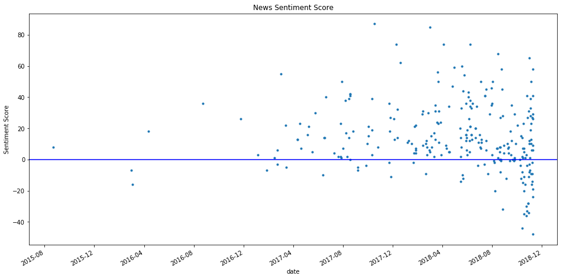

```python
%matplotlib inline

import matplotlib.pyplot as plt
from matplotlib import rcParams

rcParams['figure.figsize'] = 16,8

df = pd.read_csv('date_score.csv', parse_dates=True, index_col=1)
plt.xlabel('Date')
plt.ylabel('Sentiment Score')
plt.title('News Sentiment Score')

df['score'].plot(style=".")
plt.axhline(y=0, color='b', linestyle='-')
plt.show()
```